# Análisis Geoespacial Predio Chonchi

Zonificación para Proyecto de Carbono Forestal - 9,179 hectáreas

Pablo Cussen

28 de octubre de 2025

# 1 RESUMEN EJECUTIVO

**Ubicación:** Isla Grande de Chiloé, Región de Los Lagos, Chile  
**Área:** 9,179 hectáreas  
**Objetivo:** Zonificación para proyecto de carbono forestal

## 1.1 Hallazgos Principales

| Métrica | Valor |
| --- | --- |
| **Bosque maduro (IFM/Biochar)** | 6.333 ha (69%) |
| **Área elegible reforestación** | 254 ha (2.77%) |
| **Zonas de protección** | 1.008 ha (10.98%) |
| **Pérdida forestal 2000-2023** | 320 ha |
| **Degradación del bosque** | 4.8% del bosque histórico |

**Estado:** Elegible para proyectos bajo VM0034 (IFM) y AR-ACM0003 (Reforestación)

# 2 ZONIFICACIÓN ESTRATÉGICA

## 2.1 Metodología

La zonificación se realizó mediante análisis multi-criterio con prioridad jerárquica:

1. **Zona 3 (Protección)** - Prioridad máxima
   - Pendientes >20°
   - Turberas (SOC >6,500 g/kg)
   - Ocurrencia de agua >90%
2. **Zona 1 (IFM/Biochar)** - Bosque maduro
   - Cobertura arbórea >60%
3. **Zona 2 (Reforestación)** - Áreas degradadas
   - Cobertura arbórea <30%
   - Histórico de pérdida forestal

## 2.2 Mapa de Zonificación

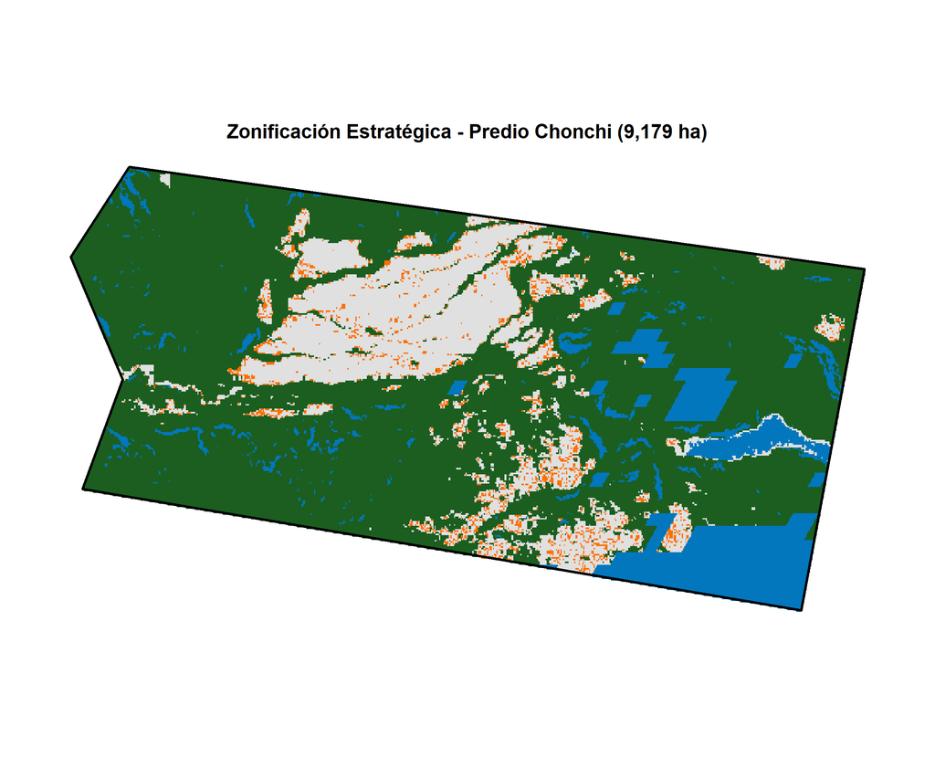

**Figura 1.** Verde oscuro: bosque maduro (IFM/Biochar). Naranja: áreas degradadas (reforestación). Azul: zonas de protección. Gris: sin asignación.

## 2.3 Distribución de Áreas

| Zona de Manejo | Hectáreas | % del Predio |
| --- | --- | --- |
| Zona 1: IFM/Biochar | 6.333,30 | 69.00% |
| Sin Asignar | 1.666,14 | 18.15% |
| Zona 3: Protección | 1.007,95 | 10.98% |
| Zona 2: Reforestación | 254,35 | 2.77% |

### 2.3.1 Zona 1: IFM/Biochar (Bosque Maduro) - 6.333 ha

**Características:** - Cobertura arbórea >60% (año 2000) - Bosque maduro sin pérdida reciente

**Metodologías aplicables:** - VM0034 - Improved Forest Management (IFM) - Producción de Biochar (secuestro permanente >1000 años)

### 2.3.2 Zona 2: Reforestación - 254 ha

**Características:** - Cobertura arbórea <30% (degradado) - Histórico documentado de bosque

**Metodologías aplicables:** - AR-ACM0003 - Afforestation and Reforestation

**Requisitos cumplidos:** - Área históricamente forestada - Pérdida forestal >10 años - Excluye turberas y cuerpos de agua

### 2.3.3 Zona 3: Protección - 1.008 ha

**Componentes:** - Turberas/Sphagnum moss (SOC >6,500 g/kg) - Pendientes altas (>20°) - Cuerpos de agua (>90% ocurrencia)

**Justificación:** No elegibles para intervención, requieren protección.

# 3 DEGRADACIÓN HISTÓRICA

## 3.1 Pérdida Forestal (2000-2023)

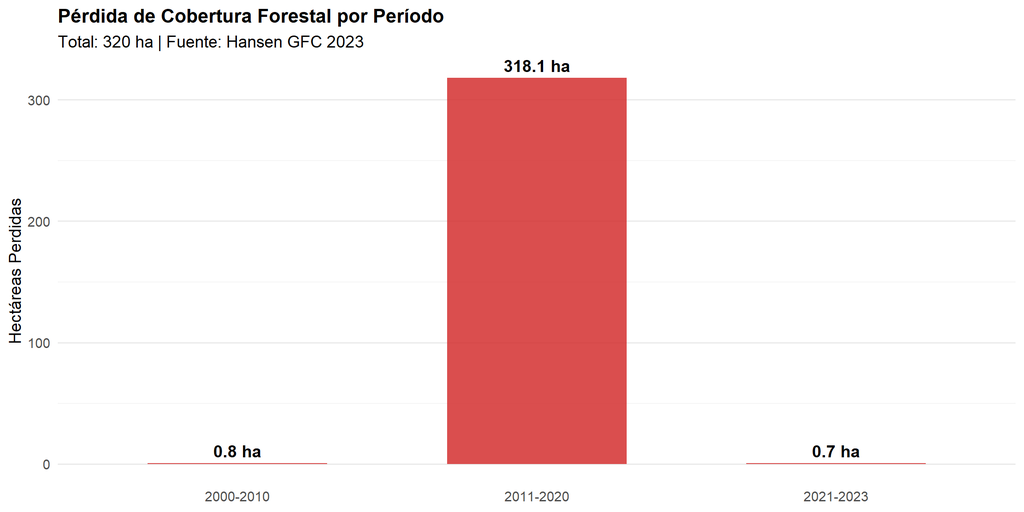

## 3.2 Análisis de Degradación

| Bosque actual (Zona 1) | 6.333 ha |
| --- | --- |
| Bosque perdido (2000-2023) | 320 ha |
| Bosque histórico (año 2000) | 6.653 ha |
| Degradación (% bosque) | 4.8% |
| Degradación (% predio) | 3.48% |

**Conclusión:** Pérdida de **320 hectáreas** representa el **4.8%** del bosque histórico. Confirma elegibilidad para proyectos de restauración.

# 4 TENDENCIA DE VEGETACIÓN (NDVI)

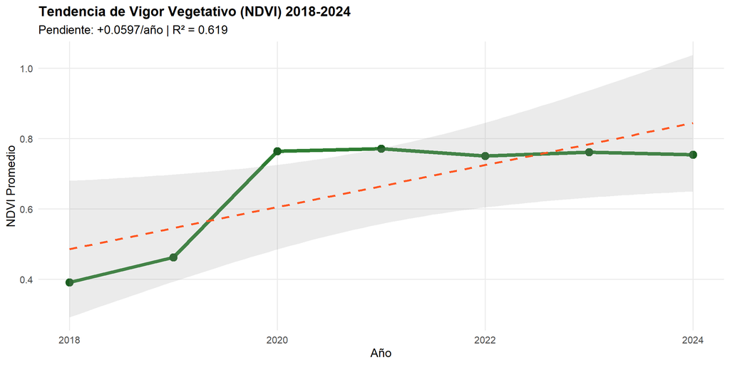

**Figura 3.** Tendencia positiva significativa (+0.06/año) indica recuperación vegetativa reciente.

# 5 CARACTERIZACIÓN DE SUELOS

## 5.1 Carbono Orgánico del Suelo (SOC)

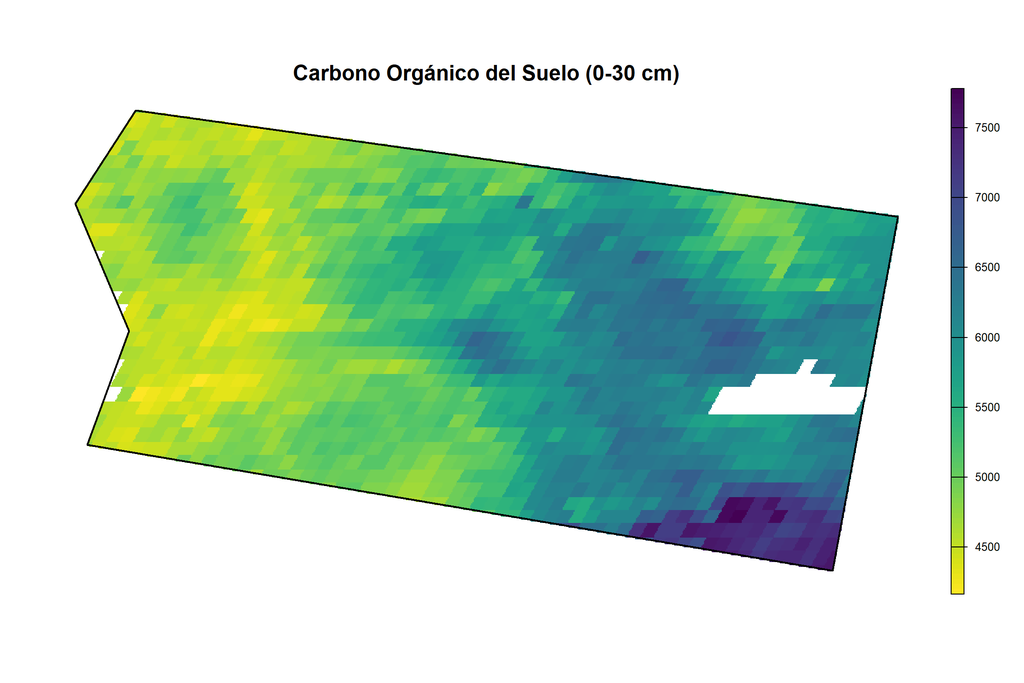

**Figura 4.** Colores más oscuros indican mayor contenido de carbono. Valores >6,500 g/kg señalan turberas.

## 5.2 Estadísticas de SOC

| Métrica | Valor |
| --- | --- |
| Mínimo | 4163 g/kg |
| Mediana | 5375 g/kg |
| Media | 5483 g/kg |
| Máximo | 7780 g/kg |
| Píxeles con SOC > 6,500 g/kg | 10.296 (7.5% del área) |

**Nota:** Píxeles con SOC >6,500 g/kg indican presencia de turberas/Sphagnum moss, clasificados en Zona 3 (Protección).

# 6 VERIFICACIÓN DE CORRECCIONES

| Observación | Resultado | Estado |
| --- | --- | --- |
| a) Área del predio = 9,179 ha | Calculada: 9179.01 ha | CORRECTO |
| b) Zona 3 > Zona 2 | Zona 3: 1008 ha \| Zona 2: 254 ha (4.0x) | CORRECTO |
| c) Zona 1 = Solo bosque maduro >60% | 6333 ha con cobertura >60% | CORRECTO |
| d) Reforestación NO en turberas | Turberas en Zona 3 (Protección) | CORRECTO |
| e) Degradación vs bosque histórico | 4.8% del bosque histórico | CORRECTO |

# 7 CONCLUSIONES

## 7.2 Próximos Pasos

### 7.2.1 Fase 1: Validación de Campo (0-3 meses)

- Inventario forestal en Zona 1
- Verificación de zonificación con GPS
- Muestreo de suelos en Zona 2

### 7.2.2 Fase 2: Desarrollo de Proyecto (3-9 meses)

- Elaborar Project Design Document (PDD)
- Análisis de viabilidad económica
- Evaluación ambiental y social

### 7.2.3 Fase 3: Validación y Registro (9-15 meses)

- Contratación de VVB
- Auditoría de validación
- Registro en Verra/Gold Standard

### 7.2.4 Fase 4: Implementación (Mes 16+)

- Implementar plan de manejo (Zona 1)
- Iniciar reforestación (Zona 2)
- Monitoreo continuo (todas las zonas)

**Informe generado:** 28 de octubre de 2025  
**Analista:** Pablo Cussen  
**Email:** pablo@cussen.cl  
**Versión:** 2.0 (Corregida)

*Análisis basado en datos satelitales de acceso público procesados en Google Earth Engine y R. Todos los datos son verificables y reproducibles.*